# A Spatial Analysis of Walkability and Urban Form in the Chicago Metropolitan Area

Shanmukh Upadhyayula

Department of Geography and GIS, University of Illinois at Urbana-Champaign

December 18, 2025

```r
library(tidyverse)
library(sf)
library(tmap)
library(knitr)
library(corrplot)
library(broom)
library(spdep)
library(scales)
library(tigris)

options(tigris_use_cache = TRUE)
```

# **Introduction**

Walkability is a measure for how safe an area is for pedestrians as well as amenities being within a reasonable walking distance. Right now, the ChiVes database does not have a walkability measure for the built environment of Chicago. Thus, adding such a measure would give an idea of what the City of Chicago could do to improve the built environment. Chicago itself already has a decently high walkability score compared to most cities in the United States, but some areas still suffer from car-friendly exclusive infrastructure. Improving the walkability score for a region would also improve the urban sustainability and the transportation equity of the city.

**Hypothesis:** Walkability will be higher in the CBD/The Loop compared to outer areas. Since there is a high population density near the center, walkability should also high. However, although it is expected that most census tracts will have an above average walkability score due to Chicago being the third most populous city in the United States, there will still be a decent chunk of census tracts in the below average range as well as the most walkable range. Thus, this project will also include population density and transit access as exploratory variables.

The goal this project is to visualize data so that there is a way to see how walkabilty varies across Chicago and whether or not higher transit access areas have a direct, inverse, or unrelated correlation with walkability. Such visualizations already exist out in on the internet, but adding it to ChiVes will place it among many other important environmental data so that everyone can see this measure in one coherent place.

# **Data Wrangling**

The dataset used for this project is the EPA National Walkability geodatabase from 2021. The data has been filtered to only include the Chicago metropolitan area by filtering the CBSA and the FIPS codes to the region. Next, the data must be cleaned to remove any possible analysis to ensure accuracy of the data. Therefore, anything with missing values have been removed.

The way that the EPA classifies walkability is out of a score of 20 that goes like the following:

**EPA Walkability Score Categories:**  
1 - 5.75: Least Walkable  
5.76 - 10.50: Below Average Walkable  
10.51 - 15.25: Above Average Walkable  
15.26 - 20: Most Walkable

The main problem with this is that the “most walkable” category is too large of a range, even if it uses the same difference of 4.76/4.75 per category. Since this is out of 20, a census tract with a score of 15.26 would be in the 76th percentile, while a census tract even just 3 points higher would be in the 91st percentile. That is why it is important to add another category. 15.26 + 4.76 = 20.02, which would make this fifth category above the scale itself. That’s why for this project, the fifth category, most walkable (the category previously called most walkable is now renamed to highly walkable), is now only at 18.1, or just slightly above the 90th percentile.

**Adjusted Categories:**

15.25 - 18.00: Highly Walkable

18 - 20: Most Walkable

The spatial scale that this data is in the format of is that of block groups. However, since ChiVes uses census tracts, the data is converted from block groups to census tracts. Since a census tracts compose of many different block groups, it is expected that there should be more block groups than census tracts. If it is the opposite, then something would be done incorrectly in the calculations. Thus, it makes sense why the number of block groups is 2.9 times higher than the number of census tracts.

Once all the cleaning is done, it is finally time to create categorical walkability variables. The EPA rates walkability on a scale from 0-20. In the code, the ranges on how walkability is categorized are shown in the **r transformations** section. The sum of all walkability category variables should equal the number of census tracts after cleaning the data.

```r
# Load the National Walkability Index data from geodatabase
walkability_raw <- st_read("WalkabilityIndex/Natl_WI.gdb",
                           layer = "NationalWalkabilityIndex")
cat("Variables available:", ncol(walkability_raw), "\n\n")
```

```
## Variables available: 30
```

```r
names(walkability_raw)
```

```
##  [1] "GEOID10"      "GEOID20"      "STATEFP"      "COUNTYFP"     "TRACTCE"
##  [6] "BLKGRPCE"     "CSA"          "CSA_Name"     "CBSA"         "CBSA_Name"
## [11] "Ac_Total"     "Ac_Water"     "Ac_Land"      "Ac_Unpr"      "TotPop"
## [16] "CountHU"      "HH"           "Workers"      "D2B_E8MIXA"   "D2A_EPHHM"
## [21] "D3B"          "D4A"          "D2A_Ranked"   "D2B_Ranked"   "D3B_Ranked"
## [26] "D4A_Ranked"   "NatWalkInd"   "Shape_Length" "Shape_Area"   "Shape"
```

```r
# Filter to Chicago metropolitan area
walkability_chicago <- walkability_raw %>%
  filter(STATEFP == "17", CBSA == "16980") %>%
  st_transform(crs = 4326)

cat("Number of block groups in Chicago metropolitan area:", nrow(walkability_chicago), "\n")
```

```
## Number of block groups in Chicago metropolitan area: 5976
```

```r
# Extract census tract ID and select variables
walkability_clean <- walkability_chicago %>%
  mutate(TRACT_GEOID = substr(GEOID10, 1, 11)) %>%
  select(
    GEOID_BG = GEOID20,
    TRACT_GEOID,
    walk_score = NatWalkInd,
    employment_entropy = D2A_EPHHM,
    intersection_density = D3B,
    transit_distance = D4A,
    total_pop = TotPop,
    total_workers = Workers,
    households = HH,
    land_area_ac = Ac_Land,
    geometry = Shape
  )

cat("Block groups before aggregation:", nrow(walkability_clean), "\n")
```

```
## Block groups before aggregation: 5976
```

```r
# Check for missing values
missing_summary <- walkability_clean %>%
  st_drop_geometry() %>%
  summarise(
    missing_walk_score = sum(is.na(walk_score)),
    missing_pop = sum(is.na(total_pop)),
    missing_transit = sum(is.na(transit_distance)),
    missing_land_area = sum(is.na(land_area_ac)),
    total_block_groups = n()
  )

print(missing_summary)
```

```
##   missing_walk_score missing_pop missing_transit missing_land_area
## 1                  0           0               0                 0
##   total_block_groups
## 1               5976
```

```r
# Remove block groups with missing data
walkability_clean <- walkability_clean %>%
  filter(!is.na(walk_score), !is.na(total_pop), !is.na(land_area_ac),
         land_area_ac > 0, walk_score > 0)

cat("\nBlock groups after cleaning:", nrow(walkability_clean), "\n")
```

```
##
## Block groups after cleaning: 5974
```

```r
# Aggregate from block groups to census tracts
tract_data <- walkability_clean %>%
  filter(!is.na(walk_score), !is.na(total_pop), !is.na(land_area_ac),
         !is.na(intersection_density), !is.na(employment_entropy),
         !is.na(transit_distance)) %>%
  group_by(TRACT_GEOID) %>%
  summarise(
    walk_score = sum(walk_score * total_pop) / sum(total_pop),
    total_pop = sum(total_pop),
    total_workers = sum(total_workers),
    households = sum(households),
    land_area_ac = sum(land_area_ac),
    intersection_density = sum(intersection_density * land_area_ac) / sum(land_area_ac),
    employment_entropy = sum(employment_entropy * total_pop) / sum(total_pop),
    transit_distance = sum(transit_distance * total_pop) / sum(total_pop),
    .groups = 'drop'
  ) %>%
  mutate(
    pop_density_sqmi = (total_pop / land_area_ac) * 640,
    workers_per_hh = total_workers / (households + 0.1),
    transit_distance_km = transit_distance / 1000
  )

cat("\nNumber of census tracts:", nrow(tract_data), "\n")
```

```
##
## Number of census tracts: 2014
```

```r
# Load ChiVes data
chives_data <- st_read("chives-data-public.geojson")
chives_clean <- chives_data %>%
  st_drop_geometry() %>%
  mutate(geoid = as.character(geoid))

tract_data_clean <- tract_data %>%
  mutate(TRACT_GEOID = as.character(TRACT_GEOID))

tract_data_with_chives <- tract_data_clean %>%
  left_join(chives_clean, by = c("TRACT_GEOID" = "geoid"))
```

```r
# Census tracts in city of Chicago
chicago_boundary <- places(state = "IL", cb = TRUE) %>%
  filter(NAME == "Chicago") %>%
  st_transform(4326)

chicago_city_tracts <- tract_data_with_chives %>%
  st_filter(chicago_boundary, .predicate = st_intersects)

num_chicago_tracts <- nrow(chicago_city_tracts)
difference <- nrow(tract_data_with_chives) - num_chicago_tracts

# Print results
cat("Census tracts in the city of Chicago:", num_chicago_tracts, "\n")
```

```
## Census tracts in the city of Chicago: 871
```

```r
cat("Difference from Greater Chicago area census tracts:", difference, "\n")
```

```
## Difference from Greater Chicago area census tracts: 1143
```

```r
cat("Percentage of census tracts in the city of Chicago:",
    floor((num_chicago_tracts / nrow(tract_data_with_chives)) * 1000) / 10, "%\n")
```

```
## Percentage of census tracts in the city of Chicago: 43.2 %
```

```r
# Create categorical walkability variable with adjusted categories
final_data <- tract_data_with_chives %>%
  mutate(
    walk_category = case_when(
      walk_score >= 18.1 ~ "Most Walkable",
      walk_score >= 15.26 & walk_score < 18.1 ~ "Highly Walkable",
      walk_score >= 10.51 & walk_score < 15.26 ~ "Above Average Walkable",
      walk_score >= 5.76 & walk_score < 10.51 ~ "Below Average Walkable",
      walk_score >= 1 & walk_score < 5.76 ~ "Least Walkable",
      TRUE ~ "No Data"
    ),
    walk_category = factor(
      walk_category,
      levels = c(
        "Least Walkable",
        "Below Average Walkable",
        "Above Average Walkable",
        "Highly Walkable",
        "Most Walkable",
        "No Data"
      )
    )
  )
```

# **Exploratory Methods**

The main approach for this model was to create statistical variables such as finding the lowest, highest, mean, median, and standard deviation walk scores. In addition, the mean population density and mean transit distance has been calculated in order to support the main walkability variables.

Once the variables are created, correlations were found among them via a correlation matrix. Then, a few statistical tests were created around these variables such as a Moran I’s test, linear regression, and ANOVA. These exploratory methods allow spatial analysis that provide important insights into Chicago.

**Reasons for each method’s inclusion:**

**Moran I’s Test:**

This test measures spatial autocorrelations, which are important in finding out whether census tracts with high or low walkability scores cluster together. For Chicago, it can show if the most walkable neighborhoods like The Loop connect easily with surrounding neighborhoods, or if the walkability is contained within the neighborhood itself.

**Linear Regression and Correlation Matrix:**

These statistical analysis quantify the relationship between the main walkability variable and exploratory variables such as population density, transit access, street intersection density, and employment entropy. Seeing the relationships between walkability and these variables can influence the sustainability and overall qaulity of life in Chicago.

**Analysis of Variance (ANOVA):**

This method compares the mean differences between contiuous variables across all five levels of walkability. Thus, it is important for seeing whether there is much of a difference in these variables between a level like “Below Average Walkable” vs “Highly Walkable”.

```r
# Summary statistics
summary_stats <- final_data %>%
  st_drop_geometry() %>%
  summarise(
    N_Tracts = n(),
    Mean_Walkability = round(mean(walk_score, na.rm = TRUE), 2),
    SD_Walkability = round(sd(walk_score, na.rm = TRUE), 2),
    Median_Walk = round(median(walk_score, na.rm = TRUE), 2),
    Min_Walk = round(min(walk_score, na.rm = TRUE), 2),
    Max_Walk = round(max(walk_score, na.rm = TRUE), 2),
    Mean_Pop_Density = round(mean(pop_density_sqmi, na.rm = TRUE), 0),
    Mean_Transit_Dist = round(mean(transit_distance_km, na.rm = TRUE), 2)
  )

kable(summary_stats, caption = "Summary Statistics for Chicago Census Tracts")
```

Summary Statistics for Chicago Census Tracts

| N_Tracts | Mean_Walkability | SD_Walkability | Median_Walk | Min_Walk | Max_Walk | Mean_Pop_Density | Mean_Transit_Dist |
| --- | --- | --- | --- | --- | --- | --- | --- |
| 2014 | 12.43 | 3.23 | 13.22 | 2.33 | 19.67 | 10098 | -77.39 |

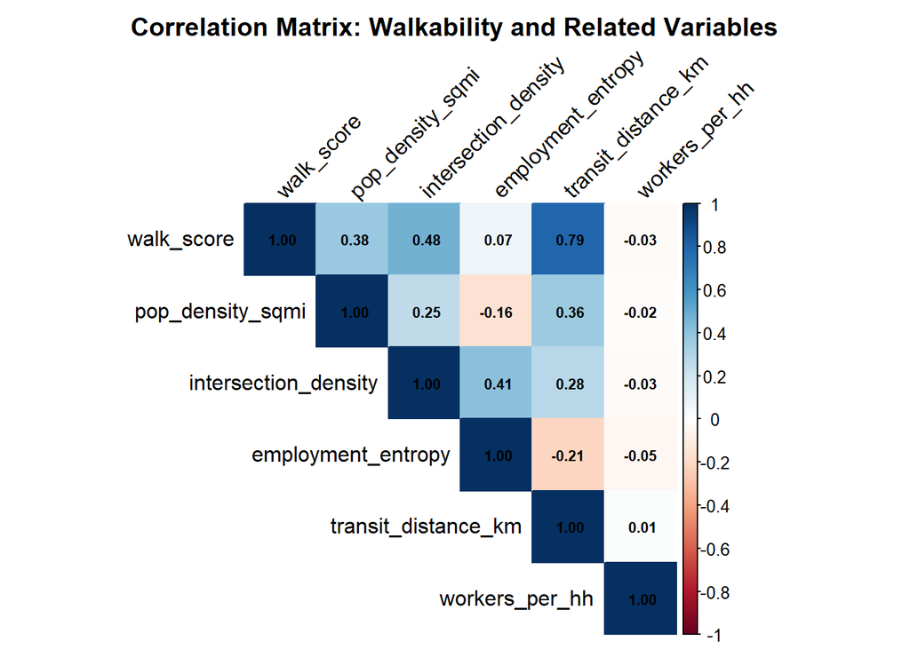

```r
# Correlation matrix
cor_data <- final_data %>%
  st_drop_geometry() %>%
  select(walk_score, pop_density_sqmi, intersection_density,
         employment_entropy, transit_distance_km, workers_per_hh) %>%
  na.omit()

cor_matrix <- cor(cor_data, use = "complete.obs")

corrplot(cor_matrix, method = "color", type = "upper",
         addCoef.col = "black", number.cex = 0.7,
         tl.col = "black", tl.srt = 45,
         title = "Correlation Matrix: Walkability and Related Variables",
         mar = c(0,0,2,0))
```

```r
# Moran's I test for spatial autocorrelation
final_data_complete <- final_data %>%
  filter(!is.na(walk_score))

coords <- st_coordinates(st_centroid(final_data_complete))
neighbors <- knn2nb(knearneigh(coords, k = 8))
weights <- nb2listw(neighbors, style = "W")

moran_test <- moran.test(final_data_complete$walk_score, weights)
cat("Moran's I test for spatial autocorrelation:\n")
```

```
## Moran's I test for spatial autocorrelation:
```

```r
print(moran_test)
```

```
##
##  Moran I test under randomisation
##
## data:  final_data_complete$walk_score
## weights: weights
##
## Moran I statistic standard deviate = 60.62, p-value < 2.2e-16
## alternative hypothesis: greater
## sample estimates:
## Moran I statistic       Expectation          Variance
##      0.6445219672     -0.0004980080      0.0001132193
```

```r
if(moran_test$p.value < 0.05) {
  cat("\nSignificant spatial autocorrelation detected (p < 0.05)")
} else {
  cat("\nNo significant spatial autocorrelation detected")
}
```

```
##
## Significant spatial autocorrelation detected (p < 0.05)
```

```r
# Linear regression
model <- lm(walk_score ~ pop_density_sqmi + transit_distance_km +
              intersection_density + employment_entropy,
            data = final_data)

summary(model)
```

```
##
## Call:
## lm(formula = walk_score ~ pop_density_sqmi + transit_distance_km +
##     intersection_density + employment_entropy, data = final_data)
##
## Residuals:
##     Min      1Q  Median      3Q     Max
## -7.9060 -1.0806 -0.0997  1.0199  6.4479
##
## Coefficients:
##                       Estimate Std. Error t value Pr(>|t|)
## (Intercept)          1.176e+01  1.013e-01 116.092  < 2e-16 ***
## pop_density_sqmi     2.240e-05  3.400e-06   6.587 5.72e-11 ***
## transit_distance_km  1.901e-02  3.468e-04  54.809  < 2e-16 ***
## intersection_density 2.065e-03  1.673e-04  12.345  < 2e-16 ***
## employment_entropy   8.019e-01  6.812e-02  11.772  < 2e-16 ***
## ---
## Signif. codes:  0 '***' 0.001 '**' 0.01 '*' 0.05 '.' 0.1 ' ' 1
##
## Residual standard error: 1.708 on 2004 degrees of freedom
##   (5 observations deleted due to missingness)
## Multiple R-squared:  0.7203, Adjusted R-squared:  0.7198
## F-statistic:  1290 on 4 and 2004 DF,  p-value: < 2.2e-16
```

```r
model_summary <- tidy(model)
kable(model_summary, digits = 3,
      caption = "Regression Results: Predictors of Walkability Score")
```

Regression Results: Predictors of Walkability Score

| term | estimate | std.error | statistic | p.value |
| --- | --- | --- | --- | --- |
| (Intercept) | 11.757 | 0.101 | 116.092 | 0 |
| pop_density_sqmi | 0.000 | 0.000 | 6.587 | 0 |
| transit_distance_km | 0.019 | 0.000 | 54.809 | 0 |
| intersection_density | 0.002 | 0.000 | 12.345 | 0 |
| employment_entropy | 0.802 | 0.068 | 11.772 | 0 |

```r
# ANOVA
anova_result <- aov(pop_density_sqmi ~ walk_category, data = final_data)
print(summary(anova_result))
```

```
##                 Df    Sum Sq   Mean Sq F value Pr(>F)
## walk_category    5 4.154e+10 8.309e+09   61.64 <2e-16 ***
## Residuals     2008 2.707e+11 1.348e+08
## ---
## Signif. codes:  0 '***' 0.001 '**' 0.01 '*' 0.05 '.' 0.1 ' ' 1
```

```r
anova_pvalue <- summary(anova_result)[[1]]$`Pr(>F)`[1]
if(!is.na(anova_pvalue) && anova_pvalue < 0.05) {
  cat("\nTukey HSD Post-hoc test:\n")
  print(TukeyHSD(anova_result))
}
```

```
##
## Tukey HSD Post-hoc test:
##   Tukey multiple comparisons of means
##     95% family-wise confidence level
##
## Fit: aov(formula = pop_density_sqmi ~ walk_category, data = final_data)
##
## $walk_category
##                                                     diff        lwr        upr
## Below Average Walkable-Least Walkable           2259.564  -2526.198  7045.3254
## Above Average Walkable-Least Walkable          10482.627   5824.454 15140.8002
## Highly Walkable-Least Walkable                 14711.617   9830.443 19592.7901
## Most Walkable-Least Walkable                   13455.725   4765.077 22146.3737
## No Data-Least Walkable                         -1180.986 -16673.959 14311.9856
## Above Average Walkable-Below Average Walkable   8223.064   6429.399 10016.7281
## Highly Walkable-Below Average Walkable         12452.053  10140.233 14763.8730
## Most Walkable-Below Average Walkable           11196.162   3643.280 18749.0437
## No Data-Below Average Walkable                 -3440.550 -18325.134 11444.0339
## Highly Walkable-Above Average Walkable          4228.989   2194.396  6263.5829
## Most Walkable-Above Average Walkable            2973.098  -4499.591 10445.7874
## No Data-Above Average Walkable                -11663.614 -26507.666  3180.4389
## Most Walkable-Highly Walkable                  -1255.891  -8869.587  6357.8046
## No Data-Highly Walkable                       -15892.603 -30808.138  -977.0683
## No Data-Most Walkable                         -14636.712 -31194.933  1921.5094
##                                                   p adj
## Below Average Walkable-Least Walkable         0.7587050
## Above Average Walkable-Least Walkable         0.0000000
## Highly Walkable-Least Walkable                0.0000000
## Most Walkable-Least Walkable                  0.0001535
## No Data-Least Walkable                        0.9999336
## Above Average Walkable-Below Average Walkable 0.0000000
## Highly Walkable-Below Average Walkable        0.0000000
## Most Walkable-Below Average Walkable          0.0003535
## No Data-Below Average Walkable                0.9862272
## Highly Walkable-Above Average Walkable        0.0000001
## Most Walkable-Above Average Walkable          0.8668672
## No Data-Above Average Walkable                0.2193239
## Most Walkable-Highly Walkable                 0.9971374
## No Data-Highly Walkable                       0.0289543
## No Data-Most Walkable                         0.1183002
```

# **Results**

The data reflects the initial hypothesis that most areas would be in the “Above Average Walkability” range. 1,090 out of 2,014 census tracts are in this range. However, this may also be due to the fact that population plays a huge role in determining a census tract boundary. Since the correlation between walkability and population density has been confirmed via the correlation matrix and the linear regression, it makes sense why over half of the census tracts belong to the “Above Average Walkability” category.

**Walkability Map for the City of Chicago versus Walkability Map for the Greater Chicago Area:**  
The visualization for the walkability scores of each census tract in Chicago describes what the paragraph above has mentioned. The larger the census tract’s land area, the more likely its walkability score is that of a lower percentile. Since the ChiVes website only visualizes the city of Chicago itself, only the main walkability map for the city will be used, but including the Greater Chicago area shows how suburban sprawl has affected the walkability of America, as many other cities have similar patterns to Chicago.

**Higher Variability Walkability Map for the City of Chicago:**

Although the adjusted fourth category and the addition of a fifth category added more variability among census tracts to produce a visualization at a higher accuracy, using a jenks style provides natural breaks in the data, which can produce a visualization where there is an even higher variability among census tracts. This uses its own categorization, which does not even count for the “Least Walkable” category, as not a single census tract within the city itself is categorized as such.

**Population Density Visualization:**

This map only exists to be able to see the correlations between walkability and population density in a map form. Obviously, many of the census tracts near The Loop have the most population density, which correlate to the most walkable census tracts. A quantile classification style has been used for this map because it spreads the data evenly across a similar number of census tracts. If jenks was used, there would be far more census tracts filled gray, making the map visually uneven.

**Street Intersection Density:**

This map helps in identifying pedestrian-centric or car-centric areas, which is helpful for understanding the impacts of a built environment’s impact on walkability and sustainability. The density of a street intersection may reveal its proximity to transit stations or other amenities that a city has to offer. A jenks classification style has been used for this map, as it uses natural breaks in the data. For a street network, it minimizes and class variances to show groupings more easily than quantile would.

**Linear Regression Visualization:**

**Economic Opportunity Visualization:**

This map has been created using the economic hardship variable is taken from the existing ChiVes dataset. The opportunity variable is an inverse of hardship. The purpose of this visualization’s inclusion in this analysis is to reveal correlations between walkability and a positive variable such as economic opportunity. Since there is no overall quality of life variable, economic opportunity is generally the best indicator of such a measure. However, there are still many other ways to draw correlations between walkability and quality of life. The census tracts with the highest economic opportunity generally align with census tracts that fall in the “high walkability” or “most walkability” categories. A jenks classification style has been used for this map, as for the same reasons as street intersection density’s.

**Scatterplot Matrix:**

This visualization shows pair relationships between walkability and several variables. There are many plots that cluster around each other.

```r
# Summary table by walkability category
results_table <- final_data %>%
  st_drop_geometry() %>%
  group_by(walk_category) %>%
  summarise(
    N_Tracts = n(),
    Mean_Walk_Score = round(mean(walk_score, na.rm = TRUE), 2),
    Total_Population = sum(total_pop, na.rm = TRUE),
    Mean_Pop_Density = round(mean(pop_density_sqmi, na.rm = TRUE), 0),
    Mean_Transit_Dist_km = round(mean(transit_distance_km, na.rm = TRUE), 2),
    Mean_Intersection_Density = round(mean(intersection_density, na.rm = TRUE), 1)
  )

kable(results_table,
      caption = "Mean Values by Walkability Category (Census Tract Level)")
```

Mean Values by Walkability Category (Census Tract Level)

| walk_category | N_Tracts | Mean_Walk_Score | Total_Population | Mean_Pop_Density | Mean_Transit_Dist_km | Mean_Intersection_Density |
| --- | --- | --- | --- | --- | --- | --- |
| Least Walkable | 53 | 5.08 | 252515 | 1181 | -249.05 | 74.7 |
| Below Average Walkable | 496 | 8.30 | 2631333 | 3441 | -246.00 | 227.8 |
| Above Average Walkable | 1090 | 13.33 | 4472854 | 11664 | -18.83 | 431.1 |
| Highly Walkable | 350 | 16.25 | 1225879 | 15893 | 0.73 | 553.0 |
| Most Walkable | 20 | 18.67 | 83160 | 14637 | 0.34 | 523.7 |
| No Data | 5 | NaN | 0 | 0 | NaN | 50.1 |

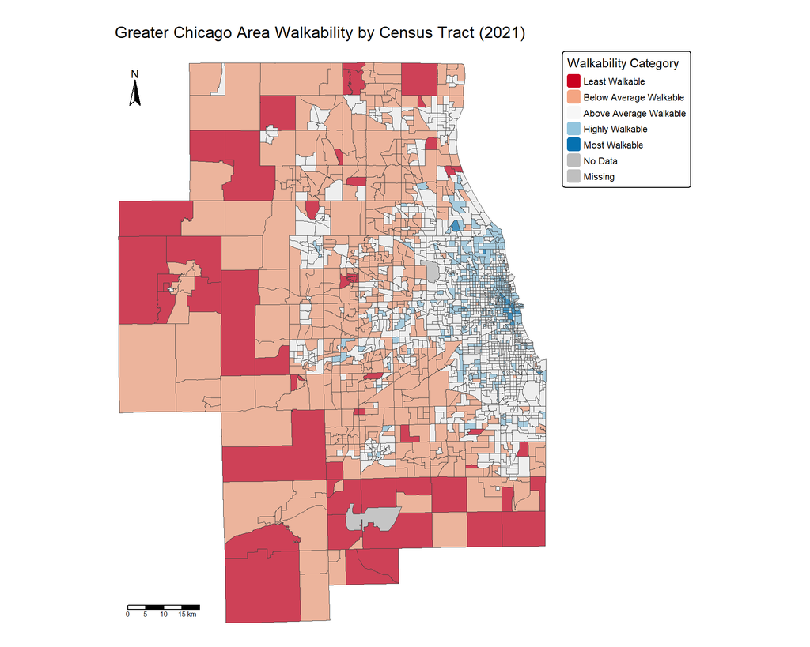

```r
tm_shape(final_data) +
  tm_fill(
    "walk_category",
    palette = c(
      "Least Walkable" = "#ca0020",
      "Below Average Walkable" = "#f4a582",
      "Above Average Walkable" = "#f7f7f7",
      "Highly Walkable" = "#92c5de",
      "Most Walkable" = "#0571b0",
      "No Data" = "#bdbdbd"
    ),
    title = "Walkability Category"
  ) +
  tm_borders(alpha = 0.3, lwd = 0.5) +
  tm_layout(
    main.title = "Greater Chicago Area Walkability by Census Tract (2021)",
    main.title.size = 1.2,
    legend.outside = TRUE,
    legend.outside.position = "right",
    frame = FALSE
  ) +
  tm_compass(position = c("left", "top")) +
  tm_scalebar(position = c("left", "bottom"))
```

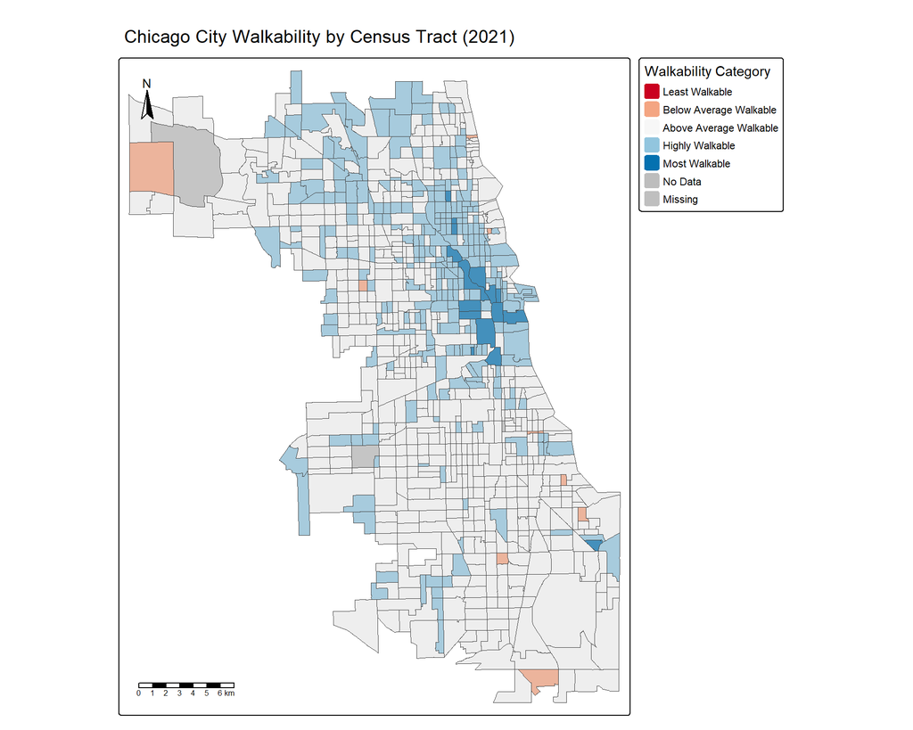

```r
# Get Chicago city boundary from Census
chicago_boundary <- places(state = "IL", cb = TRUE) %>%
  filter(NAME == "Chicago") %>%
  st_transform(4326)

chicago_city <- final_data %>%
  st_filter(chicago_boundary, .predicate = st_intersects)

# Main walkability score map
tm_shape(chicago_city) +
  tm_fill(
    "walk_category",
    palette = c(
      "Least Walkable" = "#ca0020",
      "Below Average Walkable" = "#f4a582",
      "Above Average Walkable" = "#f7f7f7",
      "Highly Walkable" = "#92c5de",
      "Most Walkable" = "#0571b0",
      "No Data" = "#bdbdbd"
    ),
    title = "Walkability Category"
  ) +
  tm_borders(alpha = 0.3, lwd = 0.5) +
  tm_layout(
    main.title = "Chicago City Walkability by Census Tract (2021)",
    main.title.size = 1.2,
    legend.outside = TRUE,
    legend.outside.position = "right",
    frame = TRUE
  ) +
  tm_compass(position = c("left", "top")) +
  tm_scalebar(position = c("left", "bottom"))
```

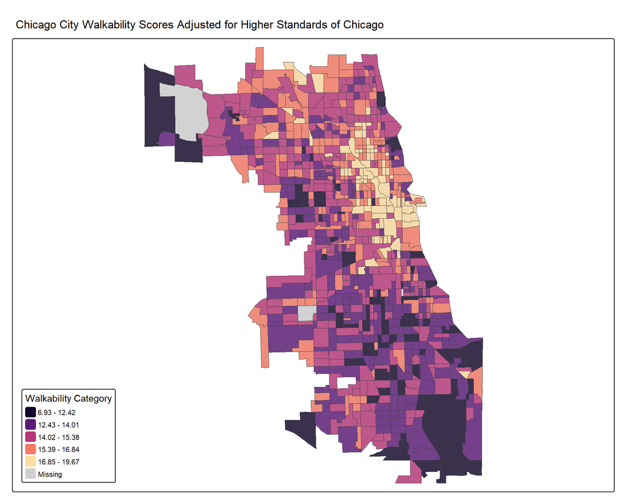

```r
# Walkability score map with higher variations
chicago_boundary <- places(state = "IL", cb = TRUE) %>%
  filter(NAME == "Chicago") %>%
  st_transform(4326)

chicago_city <- final_data %>%
  st_filter(chicago_boundary, .predicate = st_intersects)

tm0 <- tm_shape(chicago_city) +
  tm_fill("walk_score",
          palette = "magma",
          style = "jenks",
          n = 5,
          title = "Walkability Category") +
  tm_borders(alpha = 0.2, lwd = 0.3) +
  tm_layout(main.title = "Chicago City Walkability Scores Adjusted for Higher Standards of Chicago",
            legend.position = c("left", "bottom"),
            main.title.size = 1.1,
            frame = TRUE)
tmap_arrange(tm0, ncol = 1)
```

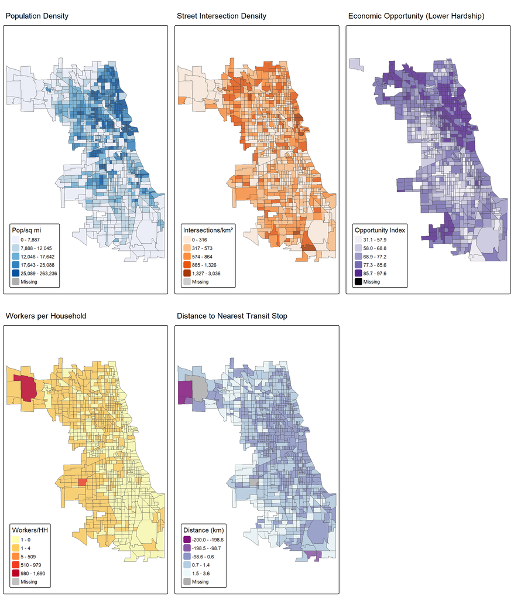

```r
# Chicago city boundary
chicago_boundary <- places(state = "IL", cb = TRUE) %>%
  filter(NAME == "Chicago") %>%
  st_transform(4326)

chicago_city <- final_data %>%
  st_filter(chicago_boundary, .predicate = st_intersects)

# Visualization 1: Population Density Map
tm1 <- tm_shape(chicago_city) +
  tm_fill("pop_density_sqmi", palette = "Blues", style = "quantile", n = 5,
          title = "Pop/sq mi") +
  tm_borders(alpha = 0.2, lwd = 0.3) +
  tm_layout(main.title = "Population Density",
            legend.position = c("left", "bottom"),
            main.title.size = 1.1,
            frame = TRUE)

# Visualization 2: Street Intersection Density
tm2 <- tm_shape(chicago_city) +
  tm_fill("intersection_density",
          palette = "Oranges",
          style = "jenks",
          n = 5,
          title = "Intersections/km²") +
  tm_borders(alpha = 0.2, lwd = 0.3) +
  tm_layout(main.title = "Street Intersection Density",
            legend.position = c("left", "bottom"),
            main.title.size = 1.1,
            frame = TRUE)

# Visualization 3: Economic Opportunity (Inverse of Hardship)

# Filter to only tracts with hardship data and invert so higher = better
chicago_city_quality <- chicago_city %>%
  filter(!is.na(hrdshpIndx)) %>%
  mutate(opportunity = 100 - hrdshpIndx)

tm3 <- tm_shape(chicago_city_quality) +
  tm_fill("opportunity",
          palette = "Purples",
          style = "jenks",
          n = 5,
          title = "Opportunity Index") +
  tm_borders(alpha = 0.2, lwd = 0.3) +
  tm_layout(main.title = "Economic Opportunity (Lower Hardship)",
            legend.position = c("left", "bottom"),
            main.title.size = 1.1,
            frame = TRUE)



# Visualization 4: Workers per Household
tm4 <- tm_shape(chicago_city) +
  tm_fill("workers_per_hh",
          palette = "YlOrRd",
          style = "jenks",
          n = 5,
          title = "Workers/HH") +
  tm_borders(alpha = 0.2, lwd = 0.3) +
  tm_layout(main.title = "Workers per Household",
            legend.position = c("left", "bottom"),
            main.title.size = 1.1,
            frame = TRUE)

# Visualization 5: Transit Distance
tm5 <- tm_shape(chicago_city) +
  tm_fill("transit_distance_km",
          palette = "-BuPu",
          style = "jenks",
          n = 5,
          title = "Distance (km)") +
  tm_borders(alpha = 0.2, lwd = 0.3) +
  tm_layout(main.title = "Distance to Nearest Transit Stop",
            legend.position = c("left", "bottom"),
            main.title.size = 1.1,
            frame = TRUE)

tmap_arrange(tm1, tm2, tm3, tm4, tm5, ncol = 3)
```

```r
# Bivariate correlations: walkability vs each mapped variable
city_stats <- final_data %>%
  st_drop_geometry() %>%
  select(walk_score, pop_density_sqmi, intersection_density,
         workers_per_hh, transit_distance_km) %>%
  na.omit()

city_quality_stats <- chicago_city_quality %>%
  st_drop_geometry() %>%
  select(walk_score, opportunity) %>%
  na.omit()

ct_pop <- cor.test(city_stats$walk_score, city_stats$pop_density_sqmi)
ct_int <- cor.test(city_stats$walk_score, city_stats$intersection_density)
ct_opp <- cor.test(city_quality_stats$walk_score, city_quality_stats$opportunity)
ct_wkr <- cor.test(city_stats$walk_score, city_stats$workers_per_hh)
ct_trn <- cor.test(city_stats$walk_score, city_stats$transit_distance_km)

tibble(
  Variable  = c("Population Density", "Street Intersection Density",
                "Economic Opportunity", "Workers per Household",
                "Transit Distance (km)"),
  r         = round(c(ct_pop$estimate, ct_int$estimate, ct_opp$estimate,
                      ct_wkr$estimate, ct_trn$estimate), 3),
  `R²`      = round(r^2, 3),
  `p-value` = c(ct_pop$p.value, ct_int$p.value, ct_opp$p.value,
                ct_wkr$p.value, ct_trn$p.value),
  Sig       = dplyr::case_when(
    `p-value` < 0.001 ~ "***",
    `p-value` < 0.01  ~ "**",
    `p-value` < 0.05  ~ "*",
    TRUE              ~ "n.s."
  )
) %>%
  mutate(`p-value` = ifelse(`p-value` < 0.001, "< 0.001",
                            as.character(round(`p-value`, 3)))) %>%
  knitr::kable(caption = "Bivariate Pearson correlations with walkability score (two-tailed)")
```

Bivariate Pearson correlations with walkability score (two-tailed)

| Variable | r | R² | p-value | Sig |
| --- | --- | --- | --- | --- |
| Population Density | 0.375 | 0.141 | < 0.001 | *** |
| Street Intersection Density | 0.478 | 0.228 | < 0.001 | *** |
| Economic Opportunity | 0.369 | 0.136 | < 0.001 | *** |
| Workers per Household | -0.029 | 0.001 | 0.195 | n.s. |
| Transit Distance (km) | 0.791 | 0.626 | < 0.001 | *** |

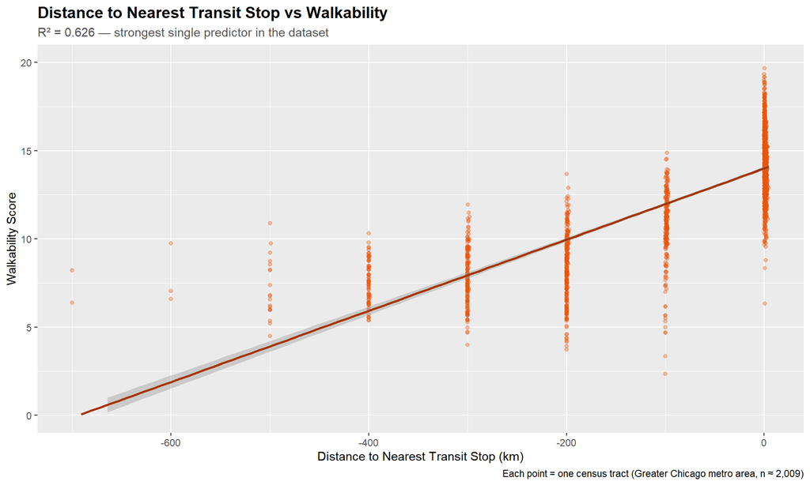

```r
scatter_data <- final_data %>% st_drop_geometry() %>%
  select(walk_score, transit_distance_km) %>% na.omit()

r2_trn <- round(cor(scatter_data$walk_score, scatter_data$transit_distance_km)^2, 3)

ggplot(scatter_data, aes(x = transit_distance_km, y = walk_score)) +
  geom_point(alpha = 0.35, color = "#e6550d") +
  geom_smooth(method = "lm", se = TRUE, color = "#a63603") +
  scale_y_continuous(limits = c(0, 20)) +
  labs(
    title = "Distance to Nearest Transit Stop vs Walkability",
    subtitle = paste0("R² = ", r2_trn, " — strongest single predictor in the dataset"),
    x = "Distance to Nearest Transit Stop (km)",
    y = "Walkability Score",
    caption = "Each point = one census tract (Greater Chicago metro area, n ≈ 2,009)"
  ) +
  theme(plot.title = element_text(size = 14, face = "bold"),
        plot.subtitle = element_text(size = 11, color = "#555"))
```

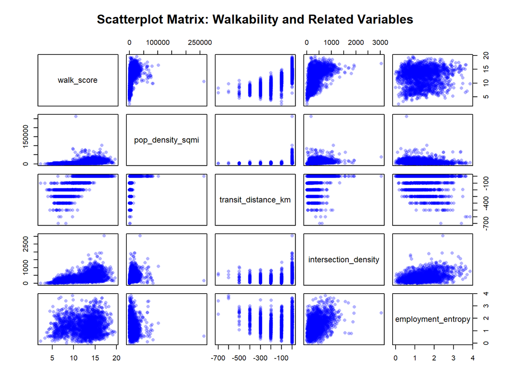

```r
# Scatterplot matrix
pairs_data <- final_data %>%
  st_drop_geometry() %>%
  select(walk_score, pop_density_sqmi, transit_distance_km,
         intersection_density, employment_entropy) %>%
  na.omit()

pairs(pairs_data,
      main = "Scatterplot Matrix: Walkability and Related Variables",
      pch = 16,
      col = rgb(0, 0, 1, 0.3))
```

# **Discussion**

Across the United States, an emerging experimental trend is the “15-minute city”, where all the amenities that come with being in a town or city can be accessed within the span of a 15 minute walk. Even in some low-density suburbs, there is demand for a reduction in car-centric infrastructure. The three maps in the additional visualizations sections all had a positive correlation with the main walkability score map. When there is a high population density, there is a tendency to build amenities closer together, which leads to a high street intersection density. When many amenities are closer together, that often leads to mixed-use buildings, which make it easier for job opportunities to rise compared to that of separating regions entirely by commercial vs residential. However, it is important to realize that there are census tracts which are exceptions to this general correlation, as seen in the regression model, implying that walkability is not an effect of the three additional variables. In other words, an area can still be relatively low-density and still have a high walkability score, which is what the aim of the “15-minute city” is.

All of these findings justify the inclusion of this dataset into ChiVes as it provides this information within the context of all of the other environmental factors that either positively or negatively influence the lives of Chicagoans on a daily basis. However, there are still a few limitations to this dataset that prevented this analysis from reaching its full potential. There are five census tracts with no data, due to them primarily not having many people at all. Furthermore, walkability scores do not account for a few aspects of the urban form, such as the quality of a sidewalk, how convenient it is to walk somewhere in warmer versus colder weather, crime rates, or how relevant an amenity is on a daily basis to the average person.

Throughout the analysis, several issues with the R code occurred. The first challenge was converting from block groups to census tracts. The initial approach to this was taking a weighted mean of the block groups, but that would have produced misleading results due to the variables for the data being counted incorrectly (i.e. not counting some data or double counting some data). It is also challenging to include a census tract if it is missing some variables. Thus, removing all data for the census tract is the easiest thing to do. Thankfully, this only removed 5/2014 census tracts. This method of computing weighted means was later changed to sum the product of a variable’s value and its corresponding weight, divided by the sum of the weights. In other words, this method accounted for the population of an area, since census tracts with larger populations contributed more proportionally to the final conversion from block groups to census tracts than lower density areas.

The next challenge was getting the exact Chicago boundaries. Initially, the spatial filtering to visualize Chicago was just using four coordinates to form a rectangle around the area. The problem with this was that areas outside the desired analysis were present in the visualization. Thus, the spatial filtering was later changed to using places function from the tigris library and transforming the location into the correct CRS. This filtered the boundaries to the exact polygon.

Then, another persistent challenge to overcome in this analysis was surprisingly loading in the ChiVes data. Usually, loading in a dataset should be simple, but the EPA Walkability variables were being incorporated into the chicago_city final data before the ChiVes variables had been incorporated into that same variable. This was solved by performing a left_join() on the EPA Walkability’s TRACT_GEOID and ChiVes’ geoid variable.

This analysis is only an introductory step in a hopefully ongoing process to bring attention to improve walkability across not just Chicago but around all of the Greater Chicago Metropolitan area as a whole. Implementing this into ChiVes would vastly increase the chances of new policy implementation such as new transit lines, added bike lanes, re-zoning projects, and new street layout projects. As previously mentioned four paragraphs back, a walkability score does not account for everything related to the convenience of pedestrians. Future work for this project could include adding data to integrate these factors into new visualizations. Perhaps an entirely new data generating process (DGP) is needed in order to maximize the accuracy of this data. In fact, the idea that 1090 census tracts are classified as “Above Average Walkability” does not make sense. If the average walkability score is singular value, it makes sense why there is no category called “Average Walkability”; Everything can only either be below or above that average. Finally, training machine learning models can speed up and also increase the accuracy of the aforementioned DGP. These models would be able to predict walkability scores based off of current built-environment variables, create new variables, and even incorporate scenario-based testing.

All of these goals and this current analysis is extremely important for the environmental sustainability and quality of life in the urban form.

# **References and .csv Export**

```r
chicago_boundary <- places(state = "IL", cb = TRUE) %>%
  filter(NAME == "Chicago") %>%
  st_transform(4326)

chicago_export <- final_data %>%
  st_filter(chicago_boundary, .predicate = st_intersects) %>%
  st_drop_geometry() %>%
  select(
    geoid = TRACT_GEOID,
    walkability_score = walk_score,
    walkability_category = walk_category,
    employment_entropy = employment_entropy,
    intersection_density = intersection_density,
    transit_distance_km = transit_distance_km,
  )

write_csv(chicago_export, "chicago_walkability_for_chives.csv")
```

- U.S. Environmental Protection Agency. (2021). National Walkability Index: User Guide and Methodology.
- U.S. Environmental Protection Agency. (2021). Smart Location Database Technical Documentation.
- ChiVes Project Team. (2024). ChiVes: Chicago Visualization and Environmental Sustainability Platform. University of Illinois at Urbana-Champaign.